# act_report

## WeRateDogs Insights and Visualization

### INTRODUCTION

The following insights were discovered from the cleaned data, with visualization to back them

1. Distribution of ratings
2. Top 10 dogs with the highest average rating
3. Most Common named dogs
1. ### Distribution of ratings

The Ratings in WeRateDogs Twitter archive has raised a lot of brows, this is because some of the Rating Numerators are higher than 10. We'll take a look at the Ratings Distribution to see what ratings are most frequent.

The Distribution of ratings as seen below is Left Skewed, We can see that the Ratings with the highest counts are 12/10 , 11/10 and 10/10.

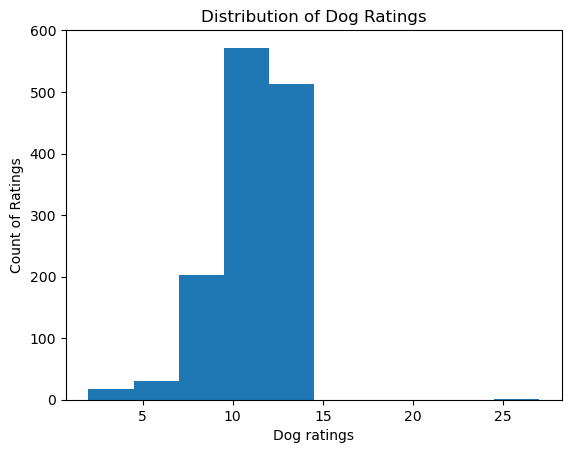

### Top 10 dogs with the highest average rating

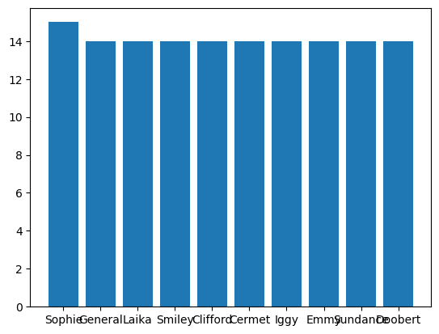

### Most Common named dogs

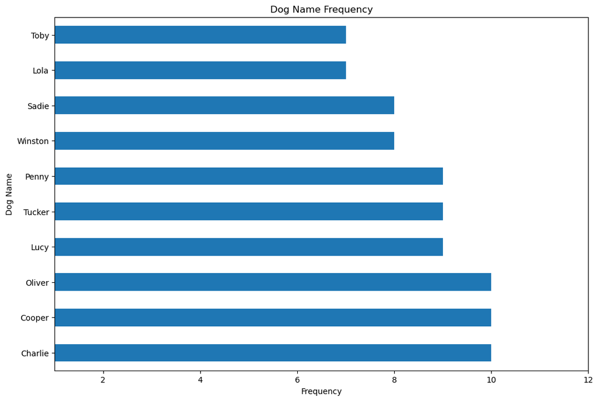

While we have serveral dog names in the datasets, We can see that the most common dog names are Charlie,Cooper and Oliver. While serveral other dogs with more unique names are named only once.

### The distribution for Tweet Sources

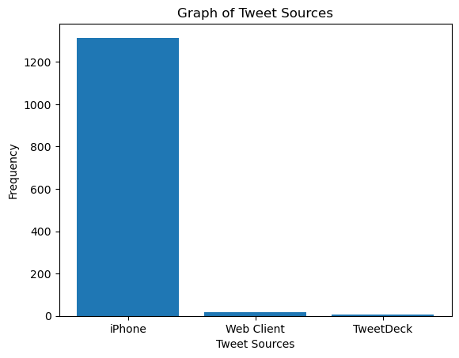

Tweet Sources tells us the device used by the account in making these tweets. From the graph of Tweet sources above , we can see that iPhone is the most common source of the three that are shown.

### Average Retweets For Each Dog Stages

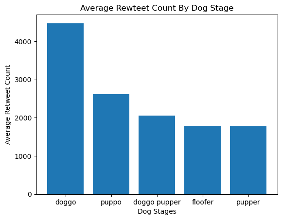